# Assignment 1: Problem I (IEC7413)

Sonia Sofia

2025-05-11

```r
# Note: install these in the console before running the script:
# install.packages("Ecdat")
# install.packages("dynlm")
# install.packages("lmtest")
# install.packages("tseries")

library(Ecdat)      # Contains the IncomeUK dataset
library(dynlm)      # For dynamic linear models
library(lmtest)     # For Ljung-Box test
library(tseries)    # For Jarque-Bera test
data(IncomeUK)

# Extract the income variable
y <- IncomeUK[, "income"]

## First-difference to induce stationarity
dy <- diff(y)

## Summary Statistics
head(IncomeUK)
```

```
##         income consumption
## 1971 Q1   9014        8016
## 1971 Q2   9659        8798
## 1971 Q3   9848        9184
## 1971 Q4  10316        9755
## 1972 Q1  10254        9113
## 1972 Q2  11271        9837
```

```r
summary(IncomeUK)
```

```
##      income       consumption
##  Min.   : 9014   Min.   : 8016
##  1st Qu.:15820   1st Qu.:13798
##  Median :27220   Median :23904
##  Mean   :30605   Mean   :26773
##  3rd Qu.:44866   3rd Qu.:38955
##  Max.   :59790   Max.   :52063
```

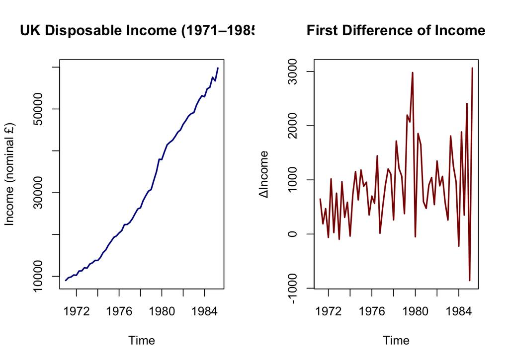

```r
# Set up the plotting area: 1 row, 2 columns
par(mfrow = c(1, 2))

# Plot original income
plot(y,
     main = "UK Disposable Income (1971–1985)",
     ylab = "Income (nominal £)",
     xlab = "Time",
     type = "l",
     col = "darkblue",
     lwd = 2)

# Plot differenced income
plot(dy,
     main = "First Difference of Income",
     ylab = "ΔIncome",
     xlab = "Time",
     type = "l",
     col = "darkred",
     lwd = 2)
```

The income data ranges from approximately £9,000 to £60,000. The average is about £30,600, but the median is only £27,200, indicating a right-skewed distribution with some high-income outliers.

The top 25% of earners (above £44,866) make nearly three times more than the bottom 25% (below £15,820), reflecting a wide income spread and a clear upward trend over time.

The left plot confirms this trend in the raw series, while the right plot shows that after differencing, the data becomes much more stable. This validates differencing as an appropriate transformation before time series modeling.

```r
# Estimate AR(p) models (p = 1 to 5) using the first-order
# difference of income
# All models should use the same number of observations

models <- list(
  AR1 = dynlm(dy ~ L(dy, 1)),
  AR2 = dynlm(dy ~ L(dy, 1:2)),
  AR3 = dynlm(dy ~ L(dy, 1:3)),
  AR4 = dynlm(dy ~ L(dy, 1:4)),
  AR5 = dynlm(dy ~ L(dy, 1:5))
)
```

## Question 1: Estimating AR(p) Models

We estimated five autoregressive (AR) models using the first-differenced income data, ranging from **AR(1)** to **AR(5)**.

Each model includes lagged values of the dependent variable and is stored in a list, allowing for efficient comparison, AIC evaluation, and residual diagnostics.

```r
# We compare AR models using Akaike's Information Criterion
# (AIC). The purpose is to identify the model with the
# lowest AIC

AIC_values <- sapply(models, AIC)
print("AIC values for each AR model:")
```

```
## [1] "AIC values for each AR model:"
```

```r
print(AIC_values)
```

```
##      AR1      AR2      AR3      AR4      AR5
## 904.9189 883.4563 869.5790 841.2757 828.0437
```

```r
# Best model according to AIC:
best_model <- names(which.min(AIC_values))
cat("\nBest model according to AIC is:", best_model, "\n")
```

```
##
## Best model according to AIC is: AR5
```

## Question 2: AIC Comparison

Out of the five AR models tested, **AR(5)** had the lowest AIC (828.04), with a 13-point improvement over **AR(4)**.

According to Burnham and Anderson (2002), a difference greater than 10 in AIC provides **strong evidence** in favor of the model with the lower value. This reinforces the selection of AR(5) as the most appropriate model in the set.

```r
# Perform Ljung-Box and Jarque-Bera tests on model residuals
# Interpret and compare results with AIC conclusions
for (name in names(models)) {
  cat("\nModel:", name, "\n")
  residuals <- resid(models[[name]])
  lb_test <- Box.test(residuals, lag = 10, type = "Ljung-Box")
  jb_test <- jarque.bera.test(residuals)
  print(lb_test)
  print(jb_test)
}
```

```
##
## Model: AR1
##
##  Box-Ljung test
##
## data:  residuals
## X-squared = 23.101, df = 10, p-value = 0.01038
##
##
##  Jarque Bera Test
##
## data:  residuals
## X-squared = 9.0294, df = 2, p-value = 0.01095
##
##
## Model: AR2
##
##  Box-Ljung test
##
## data:  residuals
## X-squared = 32.012, df = 10, p-value = 0.0003986
##
##
##  Jarque Bera Test
##
## data:  residuals
## X-squared = 3.1272, df = 2, p-value = 0.2094
##
##
## Model: AR3
##
##  Box-Ljung test
##
## data:  residuals
## X-squared = 30.446, df = 10, p-value = 0.0007238
##
##
##  Jarque Bera Test
##
## data:  residuals
```

[output cut: 14 more lines]

```
## X-squared = 2.9036, df = 2, p-value = 0.2341
##
##
## Model: AR5
##
##  Box-Ljung test
##
## data:  residuals
## X-squared = 6.0746, df = 10, p-value = 0.809
##
##
##  Jarque Bera Test
##
## data:  residuals
## X-squared = 3.0822, df = 2, p-value = 0.2141
```

```r
print(round(AIC_values, 2))
```

```
##    AR1    AR2    AR3    AR4    AR5
## 904.92 883.46 869.58 841.28 828.04
```

## Question 3: Residual Diagnostics

We tested the AR models using two diagnostic tools: the **Ljung–Box test** (to check for autocorrelation) and the **Jarque–Bera test** (to check for normality of residuals).

We used **lag = 10** because our dataset has 58 observations, and √n ≈ 7.6. Ten lags cover approximately 2.5 years of quarterly data, which aligns with typical macroeconomic practice.

**AR(4)** and **AR(5)** passed both tests, but since **AR(5)** also had the lowest AIC, it is the best overall model for inference and forecasting.

```r
cat("\nSummary:\n")
```

```
##
## Summary:
```

```r
cat("The AR(5) model had the lowest AIC and passed both residual tests,\n")
```

```
## The AR(5) model had the lowest AIC and passed both residual tests,
```

```r
cat("indicating no autocorrelation and approximate normality.\n")
```

```
## indicating no autocorrelation and approximate normality.
```

```r
cat("This model offers the best overall balance of fit and residual quality,\n")
```

```
## This model offers the best overall balance of fit and residual quality,
```

```r
cat("making it suitable for interpretation and forecasting purposes.\n")
```

```
## making it suitable for interpretation and forecasting purposes.
```